# Part 7b — Deep RL II: policy gradients, PPO and Stable-Baselines3

DQN learns **values** and derives a policy ("pick the highest Q"). Policy-gradient methods learn the **policy directly**: a network that outputs a probability for each strategy.

**Analogy.**

- *Value-based (DQN):* a food critic who scores every dish, then orders the top-scored one.
- *Policy-based (PPO):* a regular who never writes down scores, but after each meal nudges their habits: "that was good, I'll order it a bit more often in this kind of mood."

Why bother, when DQN works?

- Policy methods handle **stochastic policies** naturally. Mixing between two near-equal strategies can beat always picking one noisily.
- They extend to **continuous actions** (e.g. "allocate 30% of risk to the condor, 70% to the bull put"), where "max over actions" is impossible.
- **PPO** is the robust, general-purpose workhorse of modern deep RL.

Plan: (1) the policy-gradient idea with a tiny **REINFORCE** you write yourself, (2) PPO's key idea, the clipped objective, (3) PPO and DQN from **Stable-Baselines3** with proper validation-based model selection, (4) an honest comparison.

```python
import numpy as np, pandas as pd, matplotlib.pyplot as plt, time
import torch, torch.nn as nn
import optrl
from optrl import metrics as M
M.set_style()
torch.set_num_threads(2)
A = optrl.ACTION_NAMES
market = optrl.load_default_market()
train, test = market.split(0.7)
F = optrl.MarketData.FEATURES
stats = (train.df[F].mean().values, train.df[F].std().values)
```

## 7.4 The policy-gradient idea

The policy is a network with a softmax output: $\pi_\theta(a \mid s)$. We want to increase the expected reward $J(\theta)$. The **policy-gradient theorem** says:

$$ \nabla_\theta J = \mathbb{E}\big[\, \nabla_\theta \log \pi_\theta(a \mid s) \cdot A(s,a) \,\big] $$

*In words:* for each action you took, push up its log-probability **in proportion to how much better than expected it turned out**, the *advantage* A. Better than expected → more likely next time. Worse → less likely. Subtracting a **baseline** (what you expected) to get A instead of using raw reward doesn't change the direction on average, but it massively reduces noise. That matters a lot with P&L this noisy.

**Worked example.** Three strategies with logits [0, 0, 0] → π = [⅓, ⅓, ⅓]. You picked strategy 2 and it beat expectations: A = +0.6. For a softmax, ∇ log π(2) w.r.t. the logits is (one-hot(2) − π) = [−⅓, −⅓, +⅔]. With learning rate 0.5: logits += 0.5 · 0.6 · [−⅓, −⅓, ⅔] = [−0.1, −0.1, +0.2] → π ≈ [0.30, 0.30, **0.40**]. One good outcome made strategy 2 a bit more likely. It isn't certain, just more likely.

```python
logits = torch.zeros(3, requires_grad=True)
logp = torch.log_softmax(logits, 0)[2]
logp.backward()
print("∇ log π(2) =", logits.grad.numpy().round(3))
new = (logits + 0.5 * 0.6 * logits.grad).detach()
print("new probabilities:", torch.softmax(new, 0).numpy().round(3))
```

```
∇ log π(2) = [-0.333 -0.333  0.667]
new probabilities: [0.299 0.299 0.403]
```

### 🛠 Mini-project 7.4: REINFORCE from scratch on the weekly selection problem

Train a policy network (7 features → 32 → 8 logits) on the **contextual-bandit** version of the problem (one week = one episode, so the return is just that week's reward). Each update:

1. sample a batch of 64 training weeks;
2. sample an action per week from π;
3. advantage = reward − baseline (a running average of rewards);
4. loss = −mean(log π(a|s) · advantage) − β · entropy (the entropy bonus keeps it exploring).

Evaluate the **greedy** policy (most likely action) on the test weeks.

*Expected:* the policy learns quickly and on test earns roughly what the best single strategy does or somewhat more (≈ $50–85/week depending on the seed). Its **training** score is far higher, the same overfitting story as DQN.

```python
table = optrl.weekly_pnl_table(market)
X = optrl.decision_features(market, table); n = len(X); cut = int(n * 0.7)
mu, sd = X.iloc[:cut].mean(), X.iloc[:cut].std()
Xt = torch.tensor(((X - mu) / sd).clip(-5, 5).to_numpy(), dtype=torch.float32)
Rt = torch.tensor(table.to_numpy() / 1000, dtype=torch.float32)

def reinforce(iters=1500, batch=64, lr=3e-3, ent_coef=0.02, seed=0):
    torch.manual_seed(seed); rng = np.random.default_rng(seed)
    pi = nn.Sequential(nn.Linear(7, 32), nn.Tanh(), nn.Linear(32, 8))
    opt = torch.optim.Adam(pi.parameters(), lr=lr)
    baseline, curve = 0.0, []
    for it in range(iters):
        idx = torch.from_numpy(rng.integers(0, cut, batch))
        # TODO: build a Categorical distribution from pi(Xt[idx]), sample actions, get rewards Rt[idx, a],
        #       compute advantage, loss = -(log_prob * adv).mean() - ent_coef * entropy, and step the optimiser
    return pi, curve
```

**Solution**

```
                                        train $/wk  test $/wk
seed 0                                       251.8       48.9
seed 1                                       229.8       78.7
seed 2                                       270.9       85.8
best single strategy (chosen on train)        52.5       46.2
```

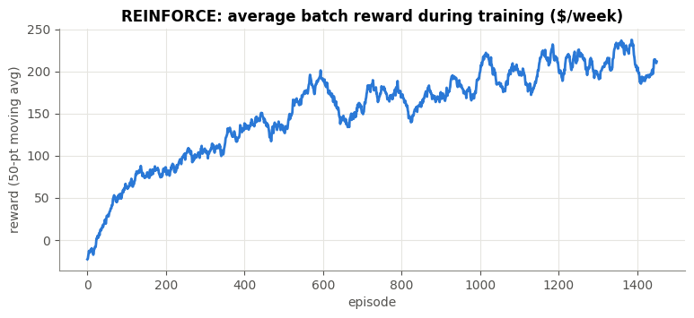

```python
def reinforce(iters=1500, batch=64, lr=3e-3, ent_coef=0.02, seed=0):
    torch.manual_seed(seed); rng = np.random.default_rng(seed)
    pi = nn.Sequential(nn.Linear(7, 32), nn.Tanh(), nn.Linear(32, 8))
    opt = torch.optim.Adam(pi.parameters(), lr=lr)
    baseline, curve = 0.0, []
    for it in range(iters):
        idx = torch.from_numpy(rng.integers(0, cut, batch))
        dist = torch.distributions.Categorical(logits=pi(Xt[idx]))
        a = dist.sample()
        r = Rt[idx, a]
        adv = r - baseline
        baseline = 0.95 * baseline + 0.05 * r.mean().item()
        loss = -(dist.log_prob(a) * adv).mean() - ent_coef * dist.entropy().mean()
        opt.zero_grad(); loss.backward(); opt.step()
        curve.append(r.mean().item())
    return pi, curve

Rn = table.to_numpy()
rows = {}
for seed in [0, 1, 2]:
    pi, curve = reinforce(seed=seed)
    with torch.no_grad():
        ch_tr, ch_te = pi(Xt[:cut]).argmax(1).numpy(), pi(Xt[cut:]).argmax(1).numpy()
    rows[f"seed {seed}"] = {"train $/wk": Rn[np.arange(cut), ch_tr].mean(), "test $/wk": Rn[np.arange(cut, n), ch_te].mean()}
rows["best single strategy (chosen on train)"] = {"train $/wk": Rn[:cut].mean(0).max(), "test $/wk": Rn[cut:, Rn[:cut].mean(0).argmax()].mean()}
print(pd.DataFrame(rows).T.round(1).to_string())
M.plot_learning_curve(np.array(curve) * 1000, w=50, title="REINFORCE: average batch reward during training ($/week)", color=M.PALETTE[0]); plt.show()
```

## 7.5 PPO: policy gradients with a safety rail

Plain REINFORCE has a flaw: one lucky batch (a crash week that made the long straddle look brilliant) can produce a huge update that wrecks a good policy. **PPO** (Proximal Policy Optimization, Schulman et al. 2017) adds two things.

**1. An actor–critic setup.** A second network head, the *critic*, learns V(s). Advantages are computed as "what actually happened" minus V(s), using GAE (generalised advantage estimation, a smooth mix of 1-step and multi-step returns). A much better baseline means much less noise.

**2. The clipped objective.** Let $\rho = \pi_{\text{new}}(a|s) / \pi_{\text{old}}(a|s)$ be how much the update changes an action's probability. PPO maximises

$$ \min\big(\rho\,A,\;\; \text{clip}(\rho,\,1-\epsilon,\,1+\epsilon)\,A\big) $$

*In words:* improve the policy, but **once an action's probability has moved more than ±ε (typically 20%) from where it was, stop pushing**. Take small, safe steps and re-evaluate.

**Trading analogy.** A risk committee that lets you tilt your strategy mix after a good month, but caps any single change at ±20% until more evidence comes in.

**Worked example** (ε = 0.2). Good action, A = +1:

- ρ = 1.1 → min(1.1, 1.1) = 1.1: still improving, keep pushing.
- ρ = 1.5 → min(1.5, **1.2**) = 1.2: clipped, so there's no gain from pushing further. The gradient is 0.

Bad action, A = −1: ρ = 0.5 → min(−0.5, −0.8) = **−0.8**, clipped at 1 − ε. Once the bad action's probability has been cut by 20%, PPO stops cutting it further on this batch.

```python
def ppo_objective(rho, A, eps=0.2):
    return np.minimum(rho * A, np.clip(rho, 1 - eps, 1 + eps) * A)

for rho, adv in [(1.1, 1), (1.5, 1), (0.5, -1), (0.9, -1)]:
    print(f"ρ={rho}, A={adv:+d} → objective {ppo_objective(rho, adv):+.2f}")
```

```
ρ=1.1, A=+1 → objective +1.10
ρ=1.5, A=+1 → objective +1.20
ρ=0.5, A=-1 → objective -0.80
ρ=0.9, A=-1 → objective -0.90
```

## 7.6 Stable-Baselines3: PPO and DQN on the trading environment

In practice you don't hand-write PPO. **Stable-Baselines3** (SB3) gives tested implementations that plug into any Gymnasium env (Part 6).

**Doing it properly: validation-based model selection.** We learned in 7a that training longer can *hurt*. So we split the training years again:

[output not shown]

Never pick models or hyperparameters on the test period. Every peek makes it less "unseen".

```python
from stable_baselines3 import PPO, DQN
from stable_baselines3.common.env_util import make_vec_env
from stable_baselines3.common.callbacks import EvalCallback
from stable_baselines3.common.monitor import Monitor

fit_mkt, val_mkt = train.split(0.8)
print("fit:", fit_mkt.df.index[0].date(), "→", fit_mkt.df.index[-1].date(),
      "| validation:", val_mkt.df.index[0].date(), "→", val_mkt.df.index[-1].date())

def make_fit_env(seed=0):
    return optrl.OptionsSelectionEnv(fit_mkt, obs_stats=stats, seed=seed)

def train_sb3(algo, total_steps, seed=0, eval_freq=5_000, **kw):
    vec = make_vec_env(lambda: make_fit_env(seed), n_envs=4 if algo is PPO else 1, seed=seed)
    val_env = Monitor(optrl.OptionsSelectionEnv(val_mkt, obs_stats=stats, episode_len=26, seed=seed + 100))
    cb = EvalCallback(val_env, n_eval_episodes=20, eval_freq=eval_freq // (4 if algo is PPO else 1),
                      deterministic=True, best_model_save_path=f"models/{algo.__name__}_s{seed}",
                      log_path=f"models/{algo.__name__}_s{seed}", verbose=0)
    model = algo("MlpPolicy", vec, seed=seed, verbose=0, **kw)
    t0 = time.time(); model.learn(total_steps, callback=cb)
    best = algo.load(f"models/{algo.__name__}_s{seed}/best_model")
    return best, model, cb, time.time() - t0

ppo_kw = dict(n_steps=256, batch_size=256, n_epochs=10, learning_rate=3e-4, gamma=0.9, gae_lambda=0.9,
              clip_range=0.2, ent_coef=0.01, policy_kwargs=dict(net_arch=[64, 64]))
ppo_best, ppo_last, ppo_cb, secs = train_sb3(PPO, 100_000, **ppo_kw)
print(f"PPO trained in {secs:.0f}s; best validation reward {ppo_cb.best_mean_reward:.3f}")

dqn_kw = dict(learning_rate=5e-4, buffer_size=50_000, learning_starts=2_000, batch_size=64, gamma=0.9,
              train_freq=4, target_update_interval=1_000, exploration_fraction=0.3, exploration_final_eps=0.05,
              policy_kwargs=dict(net_arch=[64, 64]))
dqn_best, dqn_last, dqn_cb, secs = train_sb3(DQN, 40_000, **dqn_kw)
print(f"DQN trained in {secs:.0f}s; best validation reward {dqn_cb.best_mean_reward:.3f}")
```

```
fit: 2006-01-02 → 2016-10-25 | validation: 2016-10-26 → 2019-07-10
```

```
PPO trained in 48s; best validation reward 4.783
```

```
DQN trained in 33s; best validation reward -0.425
```

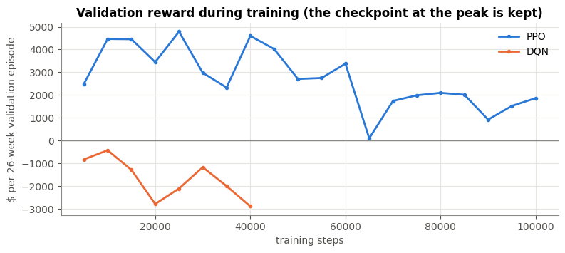

```python
fig, ax = plt.subplots(figsize=(9, 3.5))
for i, (name, cb) in enumerate([("PPO", ppo_cb), ("DQN", dqn_cb)]):
    ax.plot(cb.evaluations_timesteps, np.mean(cb.evaluations_results, axis=1) * 1000, marker="o", ms=3,
            label=name, color=M.PALETTE[i])
ax.axhline(0, color="#8a8983", lw=1); ax.set_xlabel("training steps"); ax.set_ylabel("$ per 26-week validation episode")
ax.set_title("Validation reward during training (the checkpoint at the peak is kept)"); ax.legend(); plt.show()
```

**Why the validation curve matters.** It usually rises, peaks, then wanders or falls as the agent starts memorising the fit period. `EvalCallback` keeps the checkpoint from the peak. That's early stopping, chosen **without looking at the test period**.

## 7.7 The comparison, on unseen data

```python
def sb3_policy(model):
    return lambda obs, env: int(model.predict(obs, deterministic=True)[0])

policies = {
    "PPO (best val checkpoint)": sb3_policy(ppo_best),
    "PPO (last checkpoint)": sb3_policy(ppo_last),
    "DQN (best val checkpoint)": sb3_policy(dqn_best),
    "always short_straddle": lambda o, e: 1,
    "always bull_put_spread": lambda o, e: 3,
}
runs = {k: M.full_period_rollout(optrl.OptionsSelectionEnv, test, p, obs_stats=stats) for k, p in policies.items()}
res = pd.DataFrame({k: M.summarize(v.pnl.values) for k, v in runs.items()}).T
res["cost $/wk"] = [v.cost.mean() for v in runs.values()]
print("TEST PERIOD 2019–2025:"); print(res.round(2).to_string())
```

```
TEST PERIOD 2019–2025:
                           total_pnl  mean_per_period  sharpe  max_drawdown  cvar_5%  win_rate  cost $/wk
PPO (best val checkpoint)   18505.84            61.89    0.57       8157.28 -1207.23      0.49      36.69
PPO (last checkpoint)        5483.66            18.34    0.19       9061.91 -1173.16      0.48      33.01
DQN (best val checkpoint)   15412.73            51.55    0.53       6471.10 -1163.70      0.51      42.11
always short_straddle        7950.11            26.59    1.06       2762.68  -467.45      0.71       7.02
always bull_put_spread       5559.95            18.60    0.59       2646.12  -716.94      0.75       7.89
```

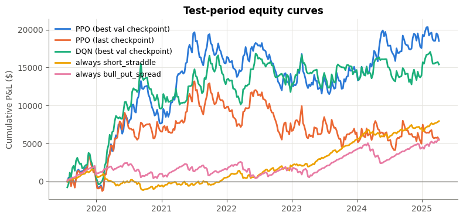

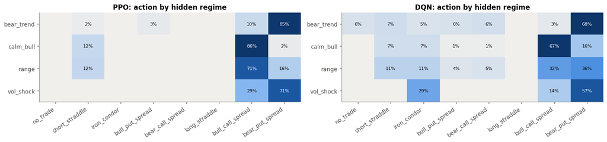

```python
M.plot_equity({k: v.set_index("date").pnl for k, v in runs.items()}, title="Test-period equity curves")
plt.show()
fig, axes = plt.subplots(1, 2, figsize=(15, 3.6))
M.plot_selection_heatmap(runs["PPO (best val checkpoint)"], row="regime", ax=axes[0], title="PPO: action by hidden regime")
M.plot_selection_heatmap(runs["DQN (best val checkpoint)"], row="regime", ax=axes[1], title="DQN: action by hidden regime")
plt.tight_layout(); plt.show()
```

**How to read this honestly.**

- Deep RL agents can beat the fixed strategies on average P&L, but often with **higher costs and deeper drawdowns**. Whether they beat them on a *risk-adjusted* basis is the real question. Look at the Sharpe and drawdown columns, not just total P&L.
- **Look at *which* strategies the agents use** (heatmaps). With reward = raw P&L, both gravitate to the **debit spreads** (bull call / bear put): large, lopsided payoffs that maximise *average* P&L when the direction call is right, at the price of big swings and a low win rate. That's what "maximise expected P&L" means literally. Exercise 7.7a changes the reward and watches the behaviour change.
- The "last checkpoint" vs "best validation checkpoint" rows show whether early stopping helped on *this* test period. It often does, though not always. It's a sound procedure, not a guarantee.
- This is **one** test period and **one** training seed. You can't yet tell skill from luck. Part 8 is devoted to exactly that.

### Peek inside PPO's policy: the Monday scenario again

PPO outputs **probabilities**. That's a nice diagnostic: a confident agent puts most of its mass on one strategy, an unsure one spreads it out.

```python
d = test.df
i = int(np.flatnonzero((d.dow == 0) & d.vix.between(13, 14) & (d.ema9 < d.ema20) & (d.days_to_earnings > 5))[-1])
e = optrl.OptionsSelectionEnv(test, obs_stats=stats); obs, _ = e.reset(options={"start": i})
with torch.no_grad():
    probs = ppo_best.policy.get_distribution(ppo_best.policy.obs_to_tensor(obs)[0]).distribution.probs[0].numpy()
print("Scenario Monday", d.index[i].date(), "| VIX", round(d.vix.iloc[i], 2), "| EMA9<EMA20 | flat")
pd.Series(probs, index=A).sort_values(ascending=False).round(3)
```

```
Scenario Monday 2024-10-21 | VIX 13.97 | EMA9<EMA20 | flat
```

```
bull_call_spread    0.842
bull_put_spread     0.053
short_straddle      0.051
iron_condor         0.023
no_trade            0.013
bear_call_spread    0.011
long_straddle       0.007
bear_put_spread     0.000
dtype: float32
```

### 🛠 Exercise 7.7a: risk-aware reward

Retrain PPO with `risk_penalty=0.5` in the **fit** environment (reward = r − 0.5·r², Part 1.4) and compare the test period's Sharpe, max drawdown and CVaR with the default PPO.

*Expected:* the penalised agent tends to avoid the high-variance debit spreads and the naked short straddle. Look for **smaller drawdowns / better CVaR**, usually with lower total P&L. Its Sharpe may or may not improve on one test period. Reward shaping changes *what* the agent optimises, so judge it on the metric you care about.

```python
# TODO: hint: write a make_env variant with risk_penalty=0.5 and reuse the train_sb3 logic
```

**Solution**

```python
def train_ppo_risk(risk, steps=100_000, seed=0):
    vec = make_vec_env(lambda: optrl.OptionsSelectionEnv(fit_mkt, obs_stats=stats, risk_penalty=risk, seed=seed), n_envs=4, seed=seed)
    val_env = Monitor(optrl.OptionsSelectionEnv(val_mkt, obs_stats=stats, episode_len=26, risk_penalty=risk, seed=seed + 100))
    cb = EvalCallback(val_env, n_eval_episodes=20, eval_freq=5_000 // 4, deterministic=True,
                      best_model_save_path=f"models/PPO_risk{risk}_s{seed}", verbose=0)
    PPO("MlpPolicy", vec, seed=seed, verbose=0, **ppo_kw).learn(steps, callback=cb)
    return PPO.load(f"models/PPO_risk{risk}_s{seed}/best_model")

ppo_risk = train_ppo_risk(0.5)
r_risk = M.full_period_rollout(optrl.OptionsSelectionEnv, test, sb3_policy(ppo_risk), obs_stats=stats)
cmp = pd.DataFrame({"PPO λ=0": M.summarize(runs["PPO (best val checkpoint)"].pnl.values),
                    "PPO λ=0.5": M.summarize(r_risk.pnl.values)}).T
print(cmp.round(2).to_string())
print("\nλ=0.5 action mix:", r_risk.action.value_counts(normalize=True).round(2).to_dict())
```

```
           total_pnl  mean_per_period  sharpe  max_drawdown  cvar_5%  win_rate
PPO λ=0     18505.84            61.89    0.57       8157.28 -1207.23      0.49
PPO λ=0.5   11840.86            39.60    1.53       2182.54  -549.75      0.79

λ=0.5 action mix: {'bull_put_spread': 0.57, 'bear_call_spread': 0.31, 'short_straddle': 0.12}
```

In the reference run the risk-penalised agent **switched from debit spreads to credit spreads and the short straddle**. It gave up about a third of its average P&L, roughly tripled its Sharpe ratio, and cut max drawdown by about 70%. For many traders **reward design is the single most valuable lever** in the whole project. It decides what "good" means.

### 🛠 Exercise 7.7b: seed sensitivity

Retrain PPO (default settings) with seeds 1 and 2 and put all three seeds' test Sharpe side by side. *Expected:* a noticeable spread between seeds, often as big as the difference between PPO and DQN above. Before you claim "PPO beats DQN", you need many seeds and a statistical test. That's Part 8.

```python
# TODO
```

**Solution**

```python
seed_rows = {"seed 0": M.summarize(runs["PPO (best val checkpoint)"].pnl.values)}
for s_ in [1, 2]:
    best_s, _, _, _ = train_sb3(PPO, 100_000, seed=s_, **ppo_kw)
    seed_rows[f"seed {s_}"] = M.summarize(M.full_period_rollout(optrl.OptionsSelectionEnv, test, sb3_policy(best_s), obs_stats=stats).pnl.values)
pd.DataFrame(seed_rows).T[["mean_per_period", "sharpe", "max_drawdown"]].round(2)
```

|  | mean_per_period | sharpe | max_drawdown |
| --- | --- | --- | --- |
| seed 0 | 61.89 | 0.57 | 8157.28 |
| seed 1 | 5.43 | 0.06 | 6257.64 |
| seed 2 | 50.02 | 0.44 | 7718.35 |

## Recap

- **Policy gradient**: push up log π(a|s) in proportion to the advantage. Baselines cut noise.
- **PPO** = actor-critic + a clipped objective (small, safe policy updates) + an entropy bonus.
- **SB3** gives you PPO/DQN in a few lines. Your job is the environment, the evaluation protocol and the judgement.
- Use a **validation period + `EvalCallback`** to pick checkpoints. Never tune on the test period.
- Single runs are anecdotes: **seeds matter**.

**Next → Part 8:** evaluation and backtesting, done properly.